# Technical review: How to approach a control system design problem?

#### A walk through example of designing controllers for Boeing 747 explained in narrative and technical style.

### Introduction:

In any control system design problem, one must take a three-step approach towards delivering a successful design.

1. The first step involves identifying the system dynamics. One must have sound knowledge in Kinematics and Dynamics to understand the forces and moments acting on the system which can be rewritten as set of nth order differential equations that can define the states of the system. Once this is available, it can be written in state space representation that can be studied using the tools of Modern control theory. Note, if we do not have any assumption about the nature of the system, it is non-linear in all cases. Based on the model we have, there are different subfields that can help us to achieve our goal. We have theory developed for linear controls, non-linear controls, adaptive controls, robust controls, model-free controls etc. to our disposal.
2. In Second step, one must identify the control inputs that can alter the state of the system to the desired. This may or may not directly be available and comes with prior knowledge/ through our design choice. At this point, one must also find ways to observe some states of the system which are not directly known. For this, one must welcome sensors to this party. Sensors help to identify the state of the system and help to design the control output. In order to have a system to be controlled, one must be able to influence the states of the sytem which is called controllability property of the system. In order to make sure the system follows a desired path, one must be able to observe the states of the system which is called observability property of the system.
3. In the last step, one must use this information to develop an appropriate control law that can help steer the system to what we desire. We usually start with a reference trajectory/ performance index which we would like to achieve for this system and try to find a best choice for the controller that can achieve. I stress upon the last step because designing a control that works is easy but to design a controller that is optimal is important. A typical reader may overlook this point. Here, there is no universal criteria for optimality. What one considers achieving and what one achieves at last defines the optimality condition.

Having said that, there are lot of choices for a controller starting with a classical PID controller, Linear Quadratic Regulator, Model Predictive Controller, Dynamic Programming, Hamiltonian methods, Optimal control theory etc. Most of these methods rely on prior knowledge about the model. We can also employ sophisticated data driven approaches like Reinforcement learning, Linear least squares methods, Gauss-Newton methods etc. to develop controllers. Before deviating further for an introductory paragraph, I would like to make a cautious remark that these three steps form three subfields and have many layers to it.

Notes about the example: In this review, we will be learning about control system design for a Boeing 747 model. It gives a holistic view about understanding the flight system dynamics, control surfaces and sensors, final controller for achieving certain performance. In our journey, we will limit ourselves to longitudinal and lateral control to keep the length under control. Below is a file image of a variant of Boeing 747.

[figure not shown]

Modes of typical aircraft: In this section, we are primarily concerned about the longitudinal pertubations and lateral pertubations. Based on the linearized equations describing the longitudinal pertubations, we can arrive at the following state space representation:

```matlab
A = [-0.0212 0.0466 0 -32.174;
    -0.2229 -0.5839 262.472 0;
    0.0001 -0.0018 -0.5015 0;
    0 0 1 0]
```

A = 4×4

-0.0212 0.0466 0 -32.1740 -0.2229 -0.5839 262.4720 0 0.0001 -0.0018 -0.5015 0 0 0 1.0000 0

```matlab
B = [0;1;0;0]
```

B = 4×1

0 1 0 0

```matlab
C = eye(4)
```

C = 4×4

1 0 0 0 0 1 0 0 0 0 1 0 0 0 0 1

```matlab
D = zeros(4,1)
```

D = 4×1

0 0 0 0

```matlab
[v,d] = eig(A)
```

v = 4×4 complex

-0.0750 + 0.0245i -0.0750 - 0.0245i -0.9930 + 0.0000i -0.9930 + 0.0000i -0.9969 + 0.0000i -0.9969 + 0.0000i 0.1171 + 0.0175i 0.1171 - 0.0175i -0.0002 - 0.0026i -0.0002 + 0.0026i -0.0006 + 0.0001i -0.0006 - 0.0001i -0.0022 + 0.0020i -0.0022 - 0.0020i 0.0008 + 0.0043i 0.0008 - 0.0043i

d = 4×4 complex

-0.5518 + 0.6869i 0.0000 + 0.0000i 0.0000 + 0.0000i 0.0000 + 0.0000i 0.0000 + 0.0000i -0.5518 - 0.6869i 0.0000 + 0.0000i 0.0000 + 0.0000i 0.0000 + 0.0000i 0.0000 + 0.0000i -0.0015 + 0.1380i 0.0000 + 0.0000i 0.0000 + 0.0000i 0.0000 + 0.0000i 0.0000 + 0.0000i -0.0015 - 0.1380i

```matlab
sys1 = ss(A,B,C,D)
```

sys1 = A = x1 x2 x3 x4 x1 -0.0212 0.0466 0 -32.17 x2 -0.2229 -0.5839 262.5 0 x3 0.0001 -0.0018 -0.5015 0 x4 0 0 1 0 B = u1 x1 0 x2 1 x3 0 x4 0 C = x1 x2 x3 x4 y1 1 0 0 0 y2 0 1 0 0 y3 0 0 1 0 y4 0 0 0 1 D = u1 y1 0 y2 0 y3 0 y4 0 Continuous-time state-space model.

```matlab
G = tf(sys1)
```

G = From input to output... 0.0466 s^2 + 0.02337 s + 0.05791 1: -------------------------------------------------- s^4 + 1.107 s^3 + 0.7987 s^2 + 0.02343 s + 0.01479 s^3 + 0.5227 s^2 + 0.01063 s + 0.003217 2: -------------------------------------------------- s^4 + 1.107 s^3 + 0.7987 s^2 + 0.02343 s + 0.01479 -0.0018 s^2 - 3.35e-05 s 3: -------------------------------------------------- s^4 + 1.107 s^3 + 0.7987 s^2 + 0.02343 s + 0.01479 -0.0018 s - 3.35e-05 4: -------------------------------------------------- s^4 + 1.107 s^3 + 0.7987 s^2 + 0.02343 s + 0.01479 Continuous-time transfer function.

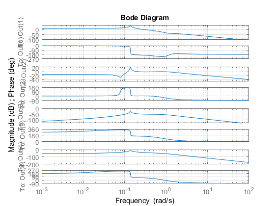

```matlab
%step(sys1)
%impulse(sys1)
bode(sys1)
%margin(sys1)
grid
```

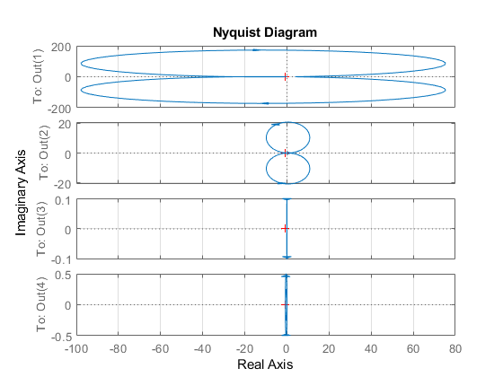

```matlab
nyquist(sys1)
grid
```

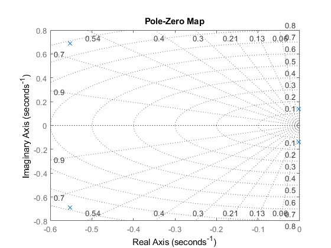

```matlab
pzmap(sys1)
grid
```

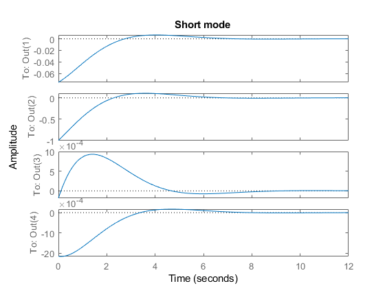

```matlab
initial(sys1, real(v(:,1)))
title('Short mode')
```

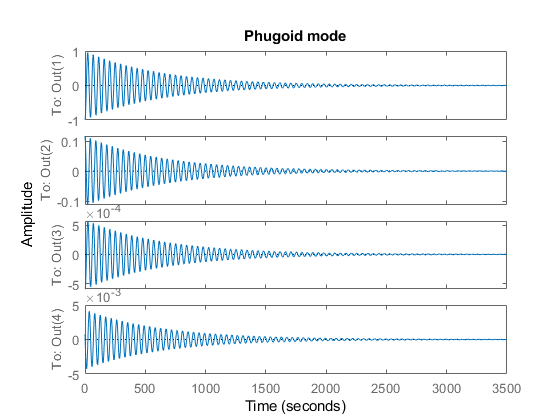

```matlab
initial(sys1, real(v(:,3)))
title('Phugoid mode')
```

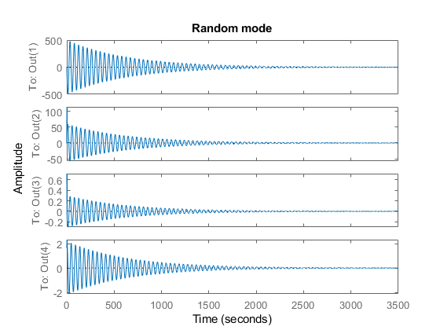

```matlab
initial(sys1, randn(4,1))
title('Random mode')
```

In the next part, we analyse the pertubation effects to lateral equilibrium. The state space representation of linearized system about the lateral equilibrium is given as follows:

```matlab
A2 = [-0.0999 0 32.174 -279.10;
       -0.0057 -1.0932 0 0.2850;
       0 1 0 0;
       0.0015 -0.0395 0 -0.2454];
B2 = [0;1;0;0]
```

B2 = 4×1

0 1 0 0

```matlab
C2 = eye(4,4)
```

C2 = 4×4

1 0 0 0 0 1 0 0 0 0 1 0 0 0 0 1

```matlab
D2 = [0;0;0;0]
```

D2 = 4×1

0 0 0 0

```matlab
sys2 = ss(A2,B2,C2,D2)
```

sys2 = A = x1 x2 x3 x4 x1 -0.0999 0 32.17 -279.1 x2 -0.0057 -1.093 0 0.285 x3 0 1 0 0 x4 0.0015 -0.0395 0 -0.2454 B = u1 x1 0 x2 1 x3 0 x4 0 C = x1 x2 x3 x4 y1 1 0 0 0 y2 0 1 0 0 y3 0 0 1 0 y4 0 0 0 1 D = u1 y1 0 y2 0 y3 0 y4 0 Continuous-time state-space model.

```matlab
[v2,d2] = eig(A2)
```

v2 = 4×4 complex

0.9986 + 0.0000i -1.0000 + 0.0000i -1.0000 + 0.0000i 0.9974 + 0.0000i 0.0415 + 0.0000i 0.0039 - 0.0023i 0.0039 + 0.0023i -0.0032 + 0.0000i -0.0338 + 0.0000i -0.0035 - 0.0048i -0.0035 + 0.0048i 0.0719 + 0.0000i 0.0001 + 0.0000i -0.0003 + 0.0021i -0.0003 - 0.0021i 0.0081 + 0.0000i

d2 = 4×4 complex

-1.2292 + 0.0000i 0.0000 + 0.0000i 0.0000 + 0.0000i 0.0000 + 0.0000i 0.0000 + 0.0000i -0.0822 + 0.7487i 0.0000 + 0.0000i 0.0000 + 0.0000i 0.0000 + 0.0000i 0.0000 + 0.0000i -0.0822 - 0.7487i 0.0000 + 0.0000i 0.0000 + 0.0000i 0.0000 + 0.0000i 0.0000 + 0.0000i -0.0448 + 0.0000i

```matlab
G2 = tf(sys2)
```

G2 = From input to output... 43.2 s + 7.895 1: ------------------------------------------------- s^4 + 1.438 s^3 + 0.8319 s^2 + 0.7318 s + 0.03125 s^3 + 0.3453 s^2 + 0.4432 s 2: ------------------------------------------------- s^4 + 1.438 s^3 + 0.8319 s^2 + 0.7318 s + 0.03125 s^2 + 0.3453 s + 0.4432 3: ------------------------------------------------- s^4 + 1.438 s^3 + 0.8319 s^2 + 0.7318 s + 0.03125 -0.0395 s^2 - 0.003946 s + 0.04826 4: ------------------------------------------------- s^4 + 1.438 s^3 + 0.8319 s^2 + 0.7318 s + 0.03125 Continuous-time transfer function.

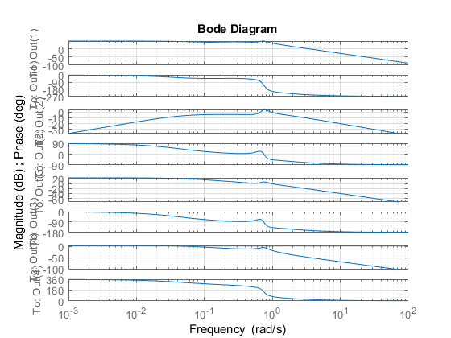

```matlab
%step(sys2)
%impulse(sys2)
bode(sys2)
grid
```

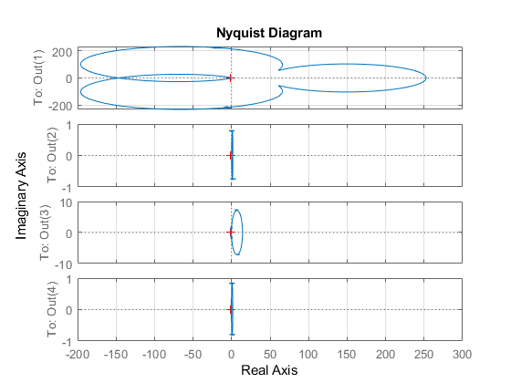

```matlab
nyquist(sys2)
grid
```

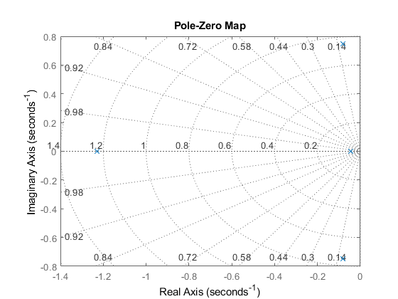

```matlab
pzmap(sys2)
grid
```

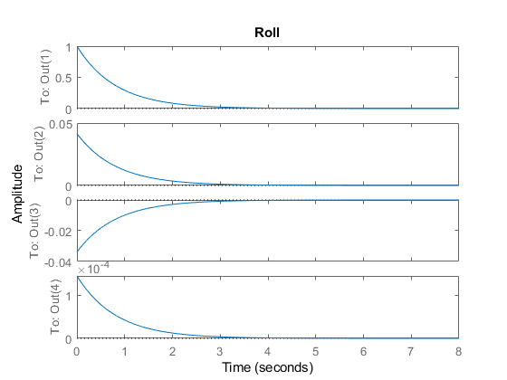

```matlab
initial(sys2, real(v2(:,1)))
title('Roll')
```

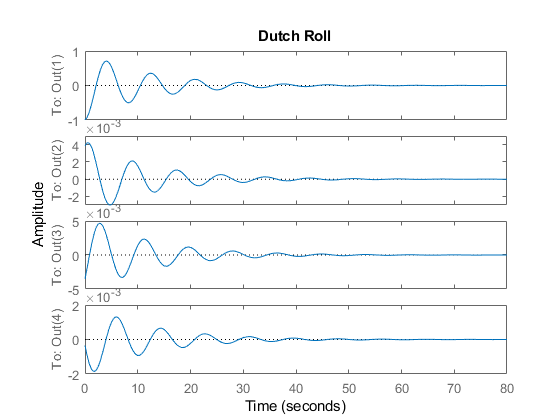

```matlab
initial(sys2, real(v2(:,2)))
title('Dutch Roll')
```

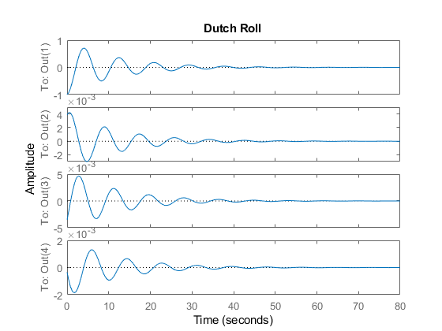

```matlab
initial(sys2, real(v2(:,3)))
title('Dutch Roll')
```

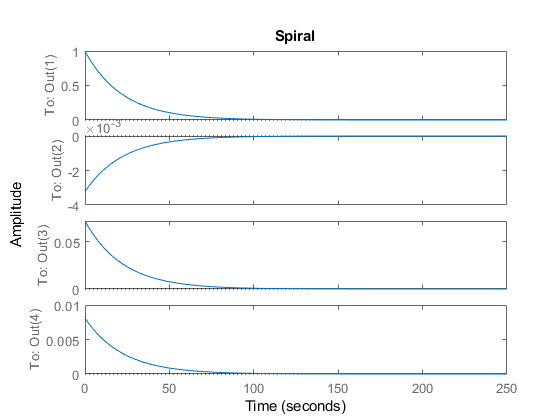

```matlab
initial(sys2, real(v2(:,4)))
title('Spiral')
```

```matlab
%sigma(sys2)
```

In general, these two pertubations in equilibrium conditions can be easily controlled. For example, to control the lateral pertubations, we can design a state feedback control by pole placement method as follows. Clearly, we can see the system is restored to equilibrium faster than normal system response as seen above.

```matlab
p = [-4 -3 -2 -1];
K = place(A2,B2, p)
```

K = 1×4

0.7899 8.5615 33.5543 59.3047

```matlab
sys3 = ss(A2-B2*K,B2,C2,D2)
```

sys3 = A = x1 x2 x3 x4 x1 -0.0999 0 32.17 -279.1 x2 -0.7956 -9.655 -33.55 -59.02 x3 0 1 0 0 x4 0.0015 -0.0395 0 -0.2454 B = u1 x1 0 x2 1 x3 0 x4 0 C = x1 x2 x3 x4 y1 1 0 0 0 y2 0 1 0 0 y3 0 0 1 0 y4 0 0 0 1 D = u1 y1 0 y2 0 y3 0 y4 0 Continuous-time state-space model.

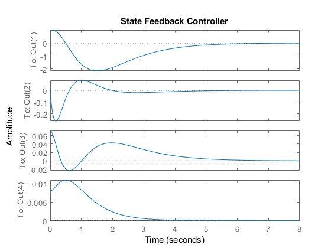

```matlab
initial(sys3, real(v2(:,4)));
title('State Feedback Controller')
```

To see a comparison between different controllers, here we use a Linear Quadratic Regulator to design the controller. Note the weight given for following state trajectory and control input.

```matlab
B2 = eye(4,1)
```

B2 = 4×1

1 0 0 0

```matlab
D2 = eye(4,1)
```

D2 = 4×1

1 0 0 0

```matlab
sys4 = ss(A2, B2, C2, D2)
```

sys4 = A = x1 x2 x3 x4 x1 -0.0999 0 32.17 -279.1 x2 -0.0057 -1.093 0 0.285 x3 0 1 0 0 x4 0.0015 -0.0395 0 -0.2454 B = u1 x1 1 x2 0 x3 0 x4 0 C = x1 x2 x3 x4 y1 1 0 0 0 y2 0 1 0 0 y3 0 0 1 0 y4 0 0 0 1 D = u1 y1 1 y2 0 y3 0 y4 0 Continuous-time state-space model.

```matlab
Q = 10*eye(4,4)
```

Q = 4×4

10 0 0 0 0 10 0 0 0 0 10 0 0 0 0 10

```matlab
R = 40
```

R = 40

```matlab
N = []
```

N = []

```matlab
[K,S,eig] = lqr(sys4, Q, R, N)
```

K = 1×4

0.3529 -5.3686 -0.0039 -38.7192

S = 4×4

10<sup>6</sup> ×

0.0000 -0.0002 -0.0000 -0.0015 -0.0002 0.0383 0.0379 -0.1164 -0.0000 0.0379 0.0420 -0.1589 -0.0015 -0.1164 -0.1589 1.5041

eig = 4×1 complex

-1.2420 + 0.0000i -0.2527 + 0.7130i -0.2527 - 0.7130i -0.0440 + 0.0000i

```matlab
sys4c = ss(A2-B2*K,B2, C2,D2)
```

sys4c = A = x1 x2 x3 x4 x1 -0.4528 5.369 32.18 -240.4 x2 -0.0057 -1.093 0 0.285 x3 0 1 0 0 x4 0.0015 -0.0395 0 -0.2454 B = u1 x1 1 x2 0 x3 0 x4 0 C = x1 x2 x3 x4 y1 1 0 0 0 y2 0 1 0 0 y3 0 0 1 0 y4 0 0 0 1 D = u1 y1 1 y2 0 y3 0 y4 0 Continuous-time state-space model.

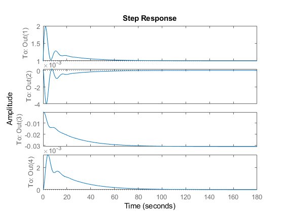

```matlab
step(sys4c)
```